# Исследование несанкционированной активности пользователей

K. Berezhinskiy

24 марта 2016 г.

Для выполнения работы, мне потребовались следующие библиотеки:

```r
library (dplyr)
library (ggplot2)
library(rworldmap)
library(knitr)
```

Загружаем исходные данные

```r
setwd("C:/r/TASK")
input<-read.csv("GeoEntrance.csv",sep=",",header=FALSE)
```

Смотрим что это за данные

```r
kable(head(input),digits = 2)
```

| V1 | V2 | V3 | V4 | V5 | V6 | V7 | V8 |
| --- | --- | --- | --- | --- | --- | --- | --- |
| 2015-04-25 | 00:01:07:726 | 2.000084e+12 | Turkey | Istanbul | 41.02 | 28.96 | Turk Telekomunikasyon Anonim Sirketi |
| 2015-04-25 | 00:02:33:815 | 2.000091e+12 | Finland |  | 60.17 | 24.94 | DNA Oy |
| 2015-04-25 | 00:02:40:090 | 2.000094e+12 | United States |  | 38.00 | -97.00 | AT&T Services, Inc. |
| 2015-04-25 | 00:02:46:882 | 2.000092e+12 | Morocco |  | 32.00 | -5.00 | MT-MPLS |
| 2015-04-25 | 00:03:28:916 | 2.000092e+12 | United States | Dyer | 36.07 | -89.05 | Gibson Electric Membership Corporation |
| 2015-04-25 | 00:03:58:812 | 2.000096e+12 | Ireland |  | 53.35 | -6.26 | Vodafone Ireland |

Забегая вперед, опытным путем было выявлено, что ни город, ни провайдер не могут служить надежным критерием для определения несанкционарованного входа, поскольку в данных столбцах много пропущенных значений.

Остается только широта и долгота.

Далее я преобразовал входную матрицу в таблицу, поле идентификатор преобразовал в фактор

```r
login<-data.frame(Date=as.Date(input[,1]),Time=input[,2],ID=as.factor(input[,3]),State=input[,4],City=input[,5],Latitude=input[,6],Longitude=input[,7],Provider=as.factor(input[,8]))
```

уже на этом этапе видна подозрительная активность пользователя 2000035408313:

```r
kable(summary.data.frame(login),digits=2)
```

|  | Date | Time | ID | State | City | Latitude | Longitude | Provider |
| --- | --- | --- | --- | --- | --- | --- | --- | --- |
|  | Min. :2015-04-23 | 17:14:05:545: 3 | 2000035408313: 3266 | Russian Federation:93726 | :143548 | Min. :-46.24 | Min. :-157.94 | OJSC Rostelecom : 26096 |
|  | 1st Qu.:2015-04-23 | 00:04:57:671: 2 | 2000007207494: 420 | Ukraine :44309 | Moscow : 7112 | 1st Qu.: 42.00 | 1st Qu.: 25.61 | JSC UKRTELECOM : 9152 |
|  | Median :2015-04-24 | 00:05:58:093: 2 | 2000010045408: 285 | Armenia :21642 | Chisinau : 4880 | Median : 50.45 | Median : 37.43 | JSC Kazakhtelecom : 6915 |
|  | Mean :2015-04-24 | 00:06:22:152: 2 | 2000058123708: 270 | United States :17971 | Saint Petersburg: 3873 | Mean : 47.06 | Mean : 27.12 | Armenia Telephone Company : 6864 |
|  | 3rd Qu.:2015-04-25 | 00:23:18:696: 2 | 840635127 : 266 | Georgia : 9392 | Minsk : 2996 | 3rd Qu.: 55.75 | 3rd Qu.: 44.79 | Republican Unitary Telecommunication Enterprise Beltelecom: 6299 |
|  | Max. :2015-04-25 | 00:46:34:136: 2 | 2000047868853: 250 | Kazakhstan : 8690 | Novosibirsk : 2108 | Max. : 69.41 | Max. : 177.41 | OJSC MegaFon : 5790 |
|  | NA | (Other) :286167 | (Other) :281423 | (Other) :90450 | (Other) :121663 | NA | NA | (Other) :225064 |

Поскольку единственная информация, которая нам доступна: широта, широта, долгота и ID извлечем из исходной таблицы их уникальные сочетания:

```r
t1<-distinct(select(login,ID,Latitude,Longitude))
kable(summary(t1),digits=2)
```

|  | ID | Latitude | Longitude |
| --- | --- | --- | --- |
|  | 2000035408313: 121 | Min. :-46.24 | Min. :-157.94 |
|  | 840635127 : 65 | 1st Qu.: 43.04 | 1st Qu.: 21.02 |
|  | 2000032004734: 64 | Median : 50.45 | Median : 34.71 |
|  | 2000007207494: 57 | Mean : 47.21 | Mean : 23.83 |
|  | 2000058123708: 41 | 3rd Qu.: 55.75 | 3rd Qu.: 43.50 |
|  | 2000009800050: 26 | Max. : 69.41 | Max. : 177.41 |
|  | (Other) :36643 | NA | NA |

Рассчитаем число уникальных записей, соответствующих одному ID в таблице t1:

```r
susp<-tapply(t1$ID,t1$ID,FUN=length)
```

Визуализируем распределение подключений, по критерию количество подключений на одного пользователя:

Агрегируем подключения выбрав в качестве критерия количество подключений (на группу 121 приходится 121 подключение):

```r
susp2<-tapply(susp,susp,sum)
susp2
```

```
##     1     2     3     4     5     6     7     8     9    11    12    16
## 26558  7046  2067   492   110    84    35    64    18    11    12    16
##    17    21    23    24    26    41    57    64    65   121
##    17    42    23    48    26    41    57    64    65   121
```

Рассчитаем количество пользователей на каждую группу (в группе 121 все 121 подключения приходятся на 1 пользователя)

```r
susp3<-as.numeric(names(susp2))
susp4<-susp2/susp3
```

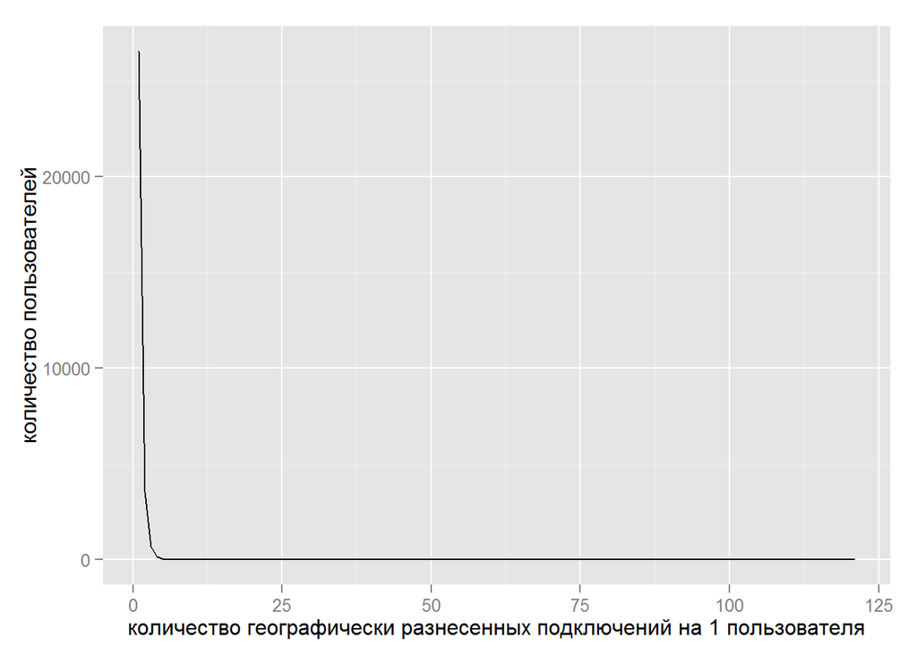

```r
qplot(susp3,y=susp4,geom="path",xlab="количество географически разнесенных подключений на 1 пользователя",ylab="количество пользователей")
```

Получаем список ID у которых есть хотя бы 2 географически разнесенных подключения

```r
susp5<-susp[susp>1]
suspID<-names(susp5)
```

Экспортируем список подозрительных пользователей:

```r
write.csv(suspID,"suspID.csv")
```

Опытным путем было установлено, что большая часть пользователей из этого списка нельзя отнести к подозрительным, возьмем на пример пользователя 3942

```r
kable(head(login[login$ID==suspID[3942],]))
```

|  | Date | Time | ID | State | City | Latitude | Longitude | Provider |
| --- | --- | --- | --- | --- | --- | --- | --- | --- |
| 11992 | 2015-04-24 | 14:27:25:964 | 2000095999613 | Ukraine |  | 50.4500 | 30.52330 | Intertelecom Ltd |
| 12642 | 2015-04-25 | 19:14:18:249 | 2000095999613 | Ukraine |  | 50.4500 | 30.52330 | Intertelecom Ltd |
| 12671 | 2015-04-25 | 19:22:15:669 | 2000095999613 | Ukraine |  | 50.4500 | 30.52330 | Intertelecom Ltd |
| 12782 | 2015-04-25 | 19:59:38:919 | 2000095999613 | Ukraine |  | 50.4500 | 30.52330 | Intertelecom Ltd |
| 12801 | 2015-04-25 | 20:04:59:817 | 2000095999613 | Ukraine |  | 50.4500 | 30.52330 | Intertelecom Ltd |
| 12993 | 2015-04-25 | 21:09:48:831 | 2000095999613 | Ukraine | Kiev | 50.4333 | 30.51669 | Intertelecom Ltd |

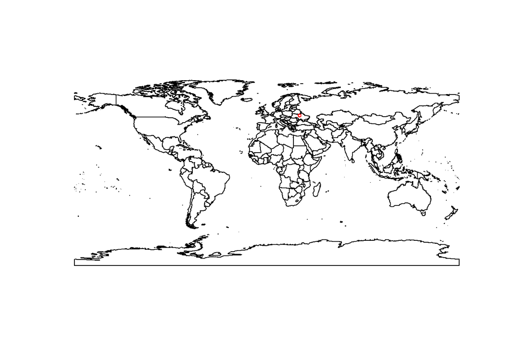

```r
newmap <- getMap(resolution = "low")
plot(newmap)
points(login$Longitude[login$ID==suspID[3942]], login$Latitude[login$ID==suspID[3942]], col = "red", cex = .6)
```

Сузить этот список можно, например, проанализировав стандартное отклонение по долготе и широте, отбросив группы пользователей с наименьшим разбросом:

```r
SDLo<-tapply(t1$Longitude,t1$ID,sd)
SDLa<-tapply(t1$Latitude,t1$ID,sd)

DF<-data.frame(sdLo=SDLo,sdLa=SDLa)
DF1<-DF[!is.na(DF$sdLo),]
DF1<-DF1[!is.na(DF1$sdLa),]
DF1$sdLoN<-scale(DF1$sdLo)
DF1$sdLaN<-scale(DF1$sdLa)
DF1$Sum<-sqrt(DF1$sdLoN^2+DF1$sdLaN^2)
DF2<-DF1
```

Кластеризуем на 3 группы

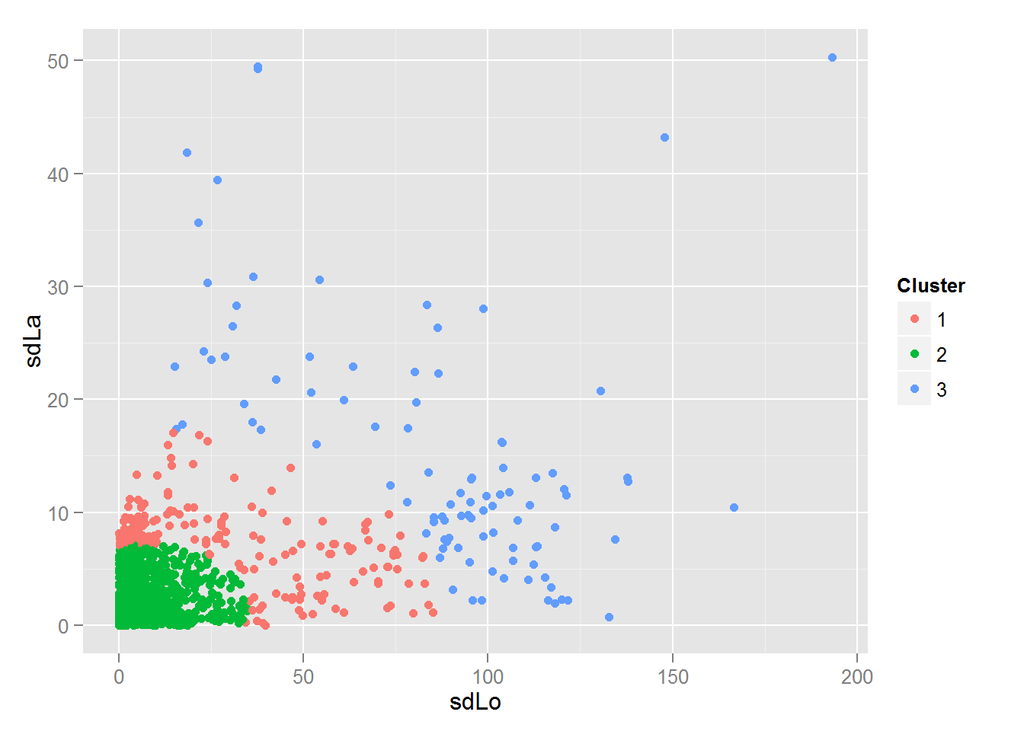

```r
km1<-kmeans(DF1$Sum,iter.max=30,alg="Lloyd",centers=3)
DF2$Cluster<-as.factor(km1$cluster)
qplot(sdLo,sdLa,colour=Cluster,data=DF2)
```

Таким образом, первоначальный список сокращается в несколько десятков раз:

```r
DF3<-DF2[DF2$Cluster==which.max(km1$centers),]
nrow(DF2)
```

```
## [1] 4401
```

```r
nrow(DF3)
```

```
## [1] 129
```